# disaggregating clarity of statistical results

Author

Ben Bolker and Jonathan Dushoff

Published

August 25, 2025

(Source code is in [this directory](https://github.com/bbolker/bbmisc/tree/master/Rmisc))

```r
library(tidyverse)
library(ggplot2); theme_set(theme_bw() + theme(panel.spacing=grid::unit(0, "lines")))
source("sim_sesoi_funs.R")
```

Simulate a $t$-test-like comparison: what is the distribution of outcomes?

We are classifying outcomes in the following way (from [here](https://dushoff.github.io/ResearchSandbox/clarStrength.Rout.pdf)/[here](https://github.com/dushoff/ResearchSandbox/blob/main/clarStrength.R):

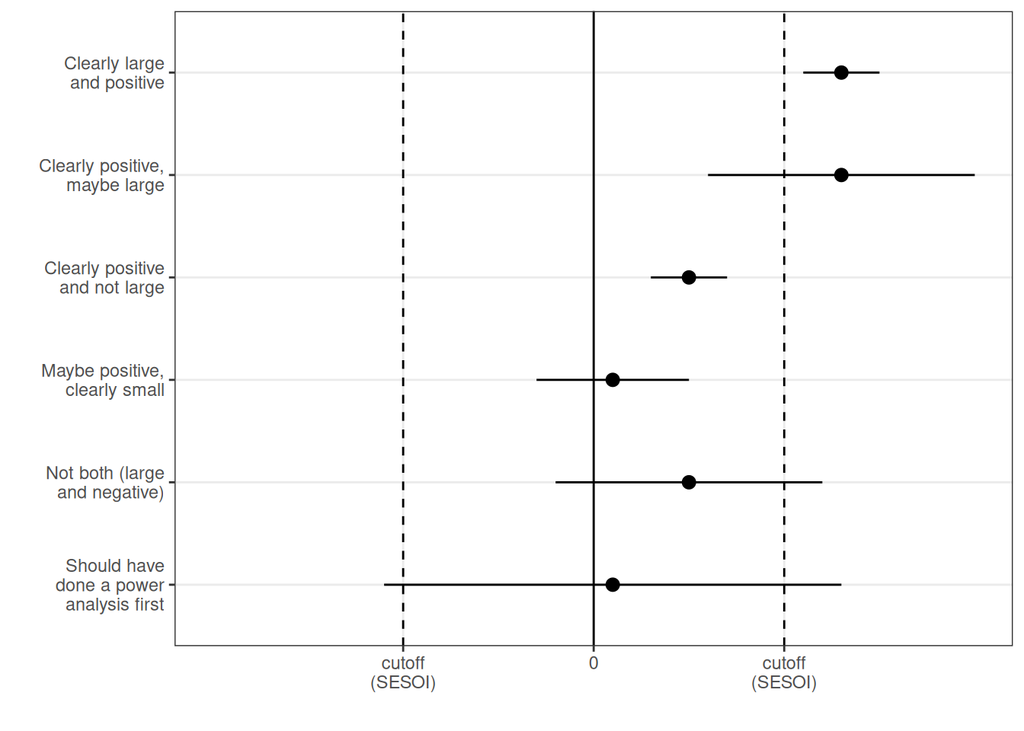

```r
largeEffect=1.3; smallEffect=0.5; tinyEffect = 0.1; smallVar = 0.2; medVar = 0.4; largeVar = 0.7; hugeVar = 1.2
span = 2
vget = Vectorize(get)
vr <- (
    read.table(header=TRUE, strip.white=TRUE, sep=":", text="
        pic : val : unc : atext : ntext
        PL : largeEffect : smallVar : Clearly large|and positive : different
        PU : largeEffect : largeVar : Clearly positive,|maybe large : different
        PS : smallEffect : smallVar : Clearly positive|and not large : different
        US : tinyEffect : medVar : Maybe positive,|clearly small : different
        UU : smallEffect : largeVar : Not both (large|and negative) : different
        nopower : tinyEffect : hugeVar : Should have|done a power|analysis first : different
    ")
)
vf <- (vr
    |> mutate(NULL
        , pic = factor(pic, levels=rev(pic))
        , val = vget(val)
        , unc = vget(unc)
        , lwr = val-unc
        , upr = val+unc
        , atext = gsub('\\|', '\n', atext)
    )
)
print(ggplot(vf)
    + aes(val, pic)
    + geom_pointrange(aes(xmin=lwr, xmax=upr))
    + theme(panel.grid.minor.x = element_blank())  ## delete vertical grid lines
    + geom_vline(xintercept=c(0, -1, 1), lty = c(1, 2, 2))
    + scale_x_continuous(limits=c(-span, span)
        , breaks = -1:1
        , labels = c("cutoff\n(SESOI)", 0 , "cutoff\n(SESOI)")
    )
    + scale_y_discrete(labels=rev(vf$atext))
  + labs(x = "", y = "")
)
```

As an example, we’ll start by determining the sample size to needed to get 80% power for a cutoff/SESOI value (`s` in the underlying code) with a standard deviation of 1:

```r
pp <- power.t.test(delta = 1, sd = 1, power = 0.8)
n <- ceiling(pp$n)  ## 17
tt <- power.t.test(delta = 1, sd = 1, n = n)
pow1 <- round(tt$power,3) ## 0.807
```

With per-sample $n$ of 17 (and with $\delta=1$, $\sigma=1$, $\alpha=0.05$) we get a power of 0.807.

If we simulate 10,000 such experiments, here is the breakdown of different outcomes:

```r
set.seed(101)
t0 <- system.time(
  tt0 <- tabfun(n=17, nsim =  10000)
)
pow1_sim <- sum(tt0[1:3])
stopifnot(all.equal(pow1_sim, tt$power, tolerance = 2e-3))
print(tt0)
```

```
            large/clear sign unclear magnitude/clear sign
                      0.0256                       0.7823
            small/clear sign           small/unclear sign
                      0.0000                       0.0216
NOT (large and opposite est)                      unclear
                      0.1705                       0.0000
```

```r
tt1 <- tabfun(n=200, nsim = 10000)
print(tt1)
```

```
            large/clear sign unclear magnitude/clear sign
                      0.0244                       0.9513
            small/clear sign           small/unclear sign
                      0.0243                       0.0000
NOT (large and opposite est)                      unclear
                      0.0000                       0.0000
```

### Simulations with $\delta=0.5$, $s=1$, varying $n$

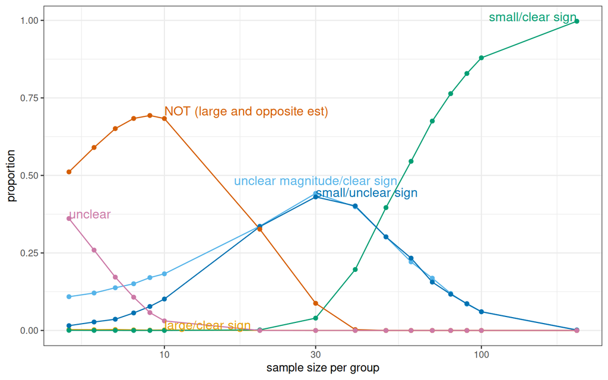

```r
## FIXME: improve piping
nvec <- c(5:10, (2:9)*10, 100, 200)
sim1 <- readRDS("sim_sesoi_batch1.rds")
printfun(f_lengthen(sim1))
```

### Simulations with $\delta=1.5$, $s=1$, varying $n$

What if we make the true effect size greater than the SESOI?

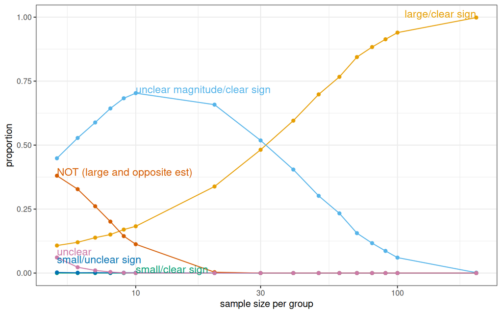

```r
sim2 <- readRDS("sim_sesoi_batch2.rds")
printfun(f_lengthen(sim2))
```

## next steps

- Shiny app?
- add ‘total power’ (i.e. sum of all ‘clear sign’ outcomes) to plots?
- other examples?
- it would be elegant and computationally efficient to figure out the analytical results for this (i.e., probably in terms of non-central $\chi^2$ distributions - Owen (1965) or Julious (2004) seem like useful starting points), although 10,000 simulations take only about 0.76 seconds (and could possibly be sped up a bit as well by eliminating overhead)
- change ‘sign’ to ‘positive’ in plots? (JD assumes a positive effect so the first plot can be labeled more clearly; maybe this is worth carrying forward)

```
R Under development (unstable) (2025-08-10 r88559)
Platform: x86_64-pc-linux-gnu
Running under: Ubuntu 24.04.3 LTS

Matrix products: default
BLAS:   /usr/local/lib/R/lib/libRblas.so
LAPACK: /usr/local/lib/R/lib/libRlapack.so;  LAPACK version 3.12.1

locale:
 [1] LC_CTYPE=en_US.UTF-8       LC_NUMERIC=C
 [3] LC_TIME=en_US.UTF-8        LC_COLLATE=en_US.UTF-8
 [5] LC_MONETARY=en_US.UTF-8    LC_MESSAGES=en_US.UTF-8
 [7] LC_PAPER=en_US.UTF-8       LC_NAME=C
 [9] LC_ADDRESS=C               LC_TELEPHONE=C
[11] LC_MEASUREMENT=en_US.UTF-8 LC_IDENTIFICATION=C

time zone: America/Toronto
tzcode source: system (glibc)

attached base packages:
[1] stats     graphics  grDevices datasets  utils     methods   base

other attached packages:
 [1] directlabels_2025.6.24 lubridate_1.9.4        forcats_1.0.0
 [4] stringr_1.5.1          dplyr_1.1.4            purrr_1.1.0
 [7] readr_2.1.5            tidyr_1.3.1            tibble_3.3.0
[10] ggplot2_3.5.2          tidyverse_2.0.0

loaded via a namespace (and not attached):
 [1] gtable_0.3.6       jsonlite_2.0.0     compiler_4.6.0     tidyselect_1.2.1
 [5] bspm_0.5.7         dichromat_2.0-0.1  scales_1.4.0       yaml_2.3.10
 [9] fastmap_1.2.0      R6_2.6.1           labeling_0.4.3     generics_0.1.4
[13] knitr_1.50         htmlwidgets_1.6.4  pillar_1.11.0      RColorBrewer_1.1-3
[17] tzdb_0.5.0         rlang_1.1.6        stringi_1.8.7      xfun_0.53
[21] quadprog_1.5-8     timechange_0.3.0   cli_3.6.5          withr_3.0.2
[25] magrittr_2.0.3     digest_0.6.37      grid_4.6.0         hms_1.1.3
[29] lifecycle_1.0.4    vctrs_0.6.5        evaluate_1.0.4     glue_1.8.0
[33] farver_2.1.2       rmarkdown_2.29     tools_4.6.0        pkgconfig_2.0.3
[37] htmltools_0.5.8.1
```

## references

Julious, Steven A. 2004. “Sample Sizes for Clinical Trials with Normal Data.” *Statistics in Medicine* 23 (12): 1921–86. https://doi.org/10.1002/sim.1783.

Owen, D. B. 1965. “A Special Case of a Bivariate Non-Central $t$-Distribution.” *Biometrika* 52 (3/4): 437–46. https://doi.org/10.2307/2333696.